Skip to main content

# Individual Major-Donor Modeling: Prospect Selection and Solicitation Features

Historical prospect-pool opportunity followed by expanding-window predictive modeling

Author

Owen Simon

Published

November 24, 2026

This report follows three analyses: historical conversion patterns by current-year giving, baseline modeling by prospect population, and incremental predictive value of solicitation features. All eligible prospects have current-year recognized giving below $1,200. The FY2025-feature/FY2026-outcome holdout is reserved for the final group evaluation.

**Data-source note:** Both the prospect-pool analysis and the modeling section reuse the same DuckDB-derived eligible constituent-year panel (`dev_panel`). Historical giving predictors are constructed from the giving aggregates, and the 23 solicitation predictors are joined from `Data_Files/solicitation_features.csv`. The campaign response measures are proxies, not causal estimates of solicitation effectiveness.

## 1. Prospect Pool Exploratory Analysis

**Question:** Are eligible constituents with any recognized giving in the current fiscal year more likely to convert to major donors in the following fiscal year than those with zero recognized giving?

Compare constituents with **current recognized giving of $0.01–$1,199.99** against those with **$0 current recognized giving**, and report following-year major-donor conversions, recognized giving, and direct cash giving. A major-donor conversion means following-year recognized giving of at least $1,200. Dollar amounts are historical observations, not incremental revenue caused by modeling.

This first stage is a descriptive analysis of four feature-year cohorts, **not** a model-validation analysis. Constituents may appear in multiple cohorts. FY2025-to-FY2026 is reserved for separate confirmation and is not included here.

### Data Preparation

Load the required R packages and PBS Utah data sources, including constituent records, payments, soft credits, campaign activity, Passport viewing, and legacy gifts. Establish the $1,200 major-donor threshold and define FY2021–FY2024 as feature years, with FY2022–FY2025 serving as their corresponding outcome years. DuckDB is used to process the source files, and fiscal years are defined as July through June.

```r
# Data manipulation and visualization
library(tidyverse)
library(scales)
library(patchwork)
library(gt)

# Database management and file paths
library(DBI)
library(duckdb)
library(here)

# Predictive modeling and evaluation
library(tidymodels)
library(pROC)
library(glmnet)
library(ranger)
library(xgboost)

major_threshold <- 1200
feature_years <- 2021:2024
outcome_years <- feature_years + 1L
last_source_fy <- 2025L

data_dir <- here("Data_Files")
stopifnot(dir.exists(data_dir))

con <- dbConnect(duckdb(), dbdir = file.path(tempdir(), "historical_conversions.duckdb"))
run_sql <- function(sql) invisible(dbExecute(con, sql))
q <- function(sql) dbGetQuery(con, sql)
run_sql("CREATE OR REPLACE MACRO fy(d) AS CASE WHEN month(TRY_CAST(d AS DATE)) >= 7 THEN year(TRY_CAST(d AS DATE)) + 1 ELSE year(TRY_CAST(d AS DATE)) END")
load_csv <- function(table, file, columns = "*") {
  path <- normalizePath(file.path(data_dir, file), winslash = "/", mustWork = TRUE)
  path <- gsub("'", "''", path, fixed = TRUE)
  run_sql(sprintf("CREATE OR REPLACE TABLE %s AS SELECT %s FROM read_csv_auto('%s', header = true, sample_size = -1, nullstr = '')", table, columns, path))
}
load_csv("payments_raw", "unite_payments.csv")
load_csv("soft_raw", "soft_credits.csv")
load_csv("constituents_raw", "constituents_w_memberships.csv")
load_csv("campaign_raw", "campaign_members.csv", "constituent_id, campaign_start_date")
load_csv("passport_raw", "passport_viewing.txt", "constituent_id, fiscal_year")
load_csv("legacy_raw", "team_approach_legacy_payments.csv", paste(c("gift_date", "payment_amount", paste0("constituent_id_", 1:7)), collapse = ", "))
```

#### Individual Eligibility

Restrict the analysis to individual constituents by excluding organizations, missing constituent IDs, and unmatched or orphan records. This maintains consistency with the original modeling population while ensuring that each constituent is identified by a unique ID.

```r
run_sql(r"---(
CREATE OR REPLACE TEMP TABLE individuals AS
SELECT "Constituent ID" AS constituent_id, "Spouse Constituent ID" AS spouse_constituent_id
FROM constituents_raw
WHERE COALESCE("Constituent ID", '') NOT IN ('', 'SYN-ORPHAN')
  AND COALESCE("Constituent Type", '') NOT ILIKE '%Organization%'
  AND COALESCE("Primary Constituent Type", '') NOT ILIKE '%Organization%'
)---")
```

#### Fiscal-Year Giving Aggregation

Deduplicate payment and soft credit records, then aggregate positive, paid direct contributions and positive soft credits by constituent and fiscal year. Recognized giving is defined as the sum of direct giving and soft credits. Legacy gift records are processed separately to establish historical activity but are excluded from the giving totals.

```r
run_sql("CREATE OR REPLACE TEMP TABLE payments_dedup AS SELECT DISTINCT * FROM payments_raw")
run_sql("CREATE OR REPLACE TEMP TABLE soft_dedup AS SELECT DISTINCT * FROM soft_raw")

run_sql(r"---(
CREATE OR REPLACE TEMP TABLE direct_fy AS
SELECT donor_id AS constituent_id, fy(credit_date)::INTEGER AS fiscal_year,
       ROUND(SUM(payment_amount)::DOUBLE, 2) AS direct_amount,
       COUNT(*)::INTEGER AS direct_payment_count
FROM payments_dedup
WHERE pledge_gift_status = 'Paid' AND payment_amount > 0
  AND donor_id IN (SELECT constituent_id FROM individuals)
  AND fy(credit_date) BETWEEN 2019 AND 2025
GROUP BY 1, 2
)---")

run_sql(r"---(
CREATE OR REPLACE TEMP TABLE soft_fy AS
SELECT "Soft Credit Constituent ID" AS constituent_id, fy("Credit Date")::INTEGER AS fiscal_year,
       ROUND(SUM("Credit Amount")::DOUBLE, 2) AS soft_amount,
       COUNT(*)::INTEGER AS soft_credit_count
FROM soft_dedup
WHERE "Credit Amount" > 0
  AND "Soft Credit Constituent ID" IN (SELECT constituent_id FROM individuals)
  AND fy("Credit Date") BETWEEN 2019 AND 2025
GROUP BY 1, 2
)---")
```

```r
# A legacy row can list up to seven household members. Unpivoting is used only to link
# dates to people; amounts and counts are never carried forward.
legacy_union <- paste(
  sprintf("SELECT gift_date, payment_amount, constituent_id_%d AS constituent_id FROM legacy_raw WHERE constituent_id_%d IS NOT NULL", 1:7, 1:7),
  collapse = " UNION ALL "
)
run_sql(paste("CREATE OR REPLACE TEMP TABLE legacy_links AS", legacy_union))
```

#### Historical Existence

Determine the earliest fiscal year in which each constituent had recorded activity across payments, soft credits, campaigns, Passport viewing, or legacy gifts. Constituents are included in a fiscal-year cohort only if their first recorded activity occurred during or before that year. This prevents constituents from entering the analysis before their earliest documented activity.

```r
existence_sources <- q(r"---(
SELECT i.constituent_id,
       p.payments_first_fy, s.soft_first_fy, c.campaign_first_fy, a.passport_first_fy,
       l.legacy_first_fy
FROM individuals i
LEFT JOIN (SELECT donor_id AS constituent_id, MIN(fy(credit_date))::INTEGER AS payments_first_fy
           FROM payments_raw WHERE fy(credit_date) <= 2025 GROUP BY 1) p USING (constituent_id)
LEFT JOIN (SELECT "Soft Credit Constituent ID" AS constituent_id, MIN(fy("Credit Date"))::INTEGER AS soft_first_fy
           FROM soft_raw WHERE fy("Credit Date") <= 2025 GROUP BY 1) s USING (constituent_id)
LEFT JOIN (SELECT constituent_id, MIN(fy(campaign_start_date))::INTEGER AS campaign_first_fy
           FROM campaign_raw WHERE fy(campaign_start_date) <= 2025 GROUP BY 1) c USING (constituent_id)
LEFT JOIN (SELECT constituent_id, MIN(fiscal_year)::INTEGER AS passport_first_fy
           FROM passport_raw WHERE fiscal_year <= 2025 GROUP BY 1) a USING (constituent_id)
LEFT JOIN (SELECT constituent_id,
                  MIN(fy(gift_date))::INTEGER AS legacy_first_fy
           FROM legacy_links WHERE gift_date IS NOT NULL GROUP BY 1) l USING (constituent_id)
)---")

existence <- existence_sources |>
  mutate(
    first_activity_fy = pmin(
      payments_first_fy, soft_first_fy, campaign_first_fy, passport_first_fy, legacy_first_fy,
      na.rm = TRUE
    )
  )
```

#### Eligible Constituent-Year Panel

Construct the development dataset by combining historical eligibility, current-year giving, and following-year giving for FY2021–FY2024 feature cohorts. Include constituents with recognized giving below $1,200 in the feature year and classify them as either Current Giving ($0.01–$1,199.99) or No Current Giving ($0). A major-donor conversion occurs when a constituent reaches at least $1,200 in recognized giving in the following fiscal year. The resulting dataset is validated for duplicate constituent-year records, fiscal-year alignment, and eligibility requirements.

```r
direct_fy <- q("SELECT constituent_id, fiscal_year, direct_amount FROM direct_fy")
soft_fy <- q("SELECT constituent_id, fiscal_year, soft_amount FROM soft_fy")

giving_year <- full_join(direct_fy, soft_fy, by = c("constituent_id", "fiscal_year")) |>
  mutate(
    direct_amount = coalesce(direct_amount, 0),
    soft_amount = coalesce(soft_amount, 0),
    recognized_amount = round(direct_amount + soft_amount, 2)
  )

next_giving <- giving_year |>
  transmute(
    constituent_id, fiscal_year = fiscal_year - 1L,
    next_direct_amount = direct_amount,
    next_soft_amount = soft_amount,
    next_recognized_amount = recognized_amount
  )

dev_panel <- existence |>
  filter(!is.na(first_activity_fy)) |>
  select(constituent_id, first_activity_fy) |>
  crossing(fiscal_year = feature_years) |>
  filter(first_activity_fy <= fiscal_year) |>
  left_join(giving_year, by = c("constituent_id", "fiscal_year")) |>
  mutate(across(c(direct_amount, soft_amount, recognized_amount), ~coalesce(.x, 0))) |>
  filter(recognized_amount >= 0, recognized_amount < major_threshold) |>
  left_join(next_giving, by = c("constituent_id", "fiscal_year")) |>
  mutate(
    across(c(next_direct_amount, next_soft_amount, next_recognized_amount), ~coalesce(.x, 0)),
    outcome_fy = fiscal_year + 1L,
    current_donor = as.integer(recognized_amount > 0),
    giving_group = if_else(current_donor == 1L, "Current Giving", "No Current Giving"),
    major_donor_next_fy = as.integer(next_recognized_amount >= major_threshold)
  ) |>
  select(constituent_id, fiscal_year, outcome_fy, first_activity_fy,
         giving_group, current_donor, direct_amount, soft_amount, recognized_amount,
         next_direct_amount, next_soft_amount, next_recognized_amount, major_donor_next_fy)

stopifnot(
  nrow(dev_panel) == nrow(distinct(dev_panel, constituent_id, fiscal_year)),
  all(dev_panel$fiscal_year %in% feature_years),
  all(dev_panel$outcome_fy == dev_panel$fiscal_year + 1L),
  all(dev_panel$first_activity_fy <= dev_panel$fiscal_year),
  all(dev_panel$recognized_amount >= 0 & dev_panel$recognized_amount < major_threshold),
  all(dev_panel$major_donor_next_fy == as.integer(dev_panel$next_recognized_amount >= major_threshold))
)

tibble(eligible_constituent_years = nrow(dev_panel),
       major_donor_conversions = sum(dev_panel$major_donor_next_fy)) |>
  gt() |>
  tab_header(title = "Eligible Development Cohorts") |>
  cols_label(eligible_constituent_years = "Eligible constituent-years",
             major_donor_conversions = "Major-donor conversions") |>
  fmt_number(columns = everything(), decimals = 0)
```

Eligible Development Cohorts

| Eligible constituent-years | Major-donor conversions |
| --- | --- |
| 615,331 | 207 |

### Historical Giving Inactivity

```r
# Establish the FY2025 eligible constituent population
fy2025_population <- existence |>
  filter(!is.na(first_activity_fy), first_activity_fy <= 2025) |>
  distinct(constituent_id)

# Calculate giving over both periods
giving_inactivity <- fy2025_population |>
  left_join(
    giving_year |>
      filter(fiscal_year >= 2021, fiscal_year <= 2025) |>
      group_by(constituent_id) |>
      summarise(
        direct_1yr = sum(direct_amount[fiscal_year == 2025], na.rm = TRUE),
        soft_1yr = sum(soft_amount[fiscal_year == 2025], na.rm = TRUE),
        recognized_1yr = sum(recognized_amount[fiscal_year == 2025], na.rm = TRUE),

        direct_5yr = sum(direct_amount, na.rm = TRUE),
        soft_5yr = sum(soft_amount, na.rm = TRUE),
        recognized_5yr = sum(recognized_amount, na.rm = TRUE),

        .groups = "drop"
      ),
    by = "constituent_id"
  ) |>
  mutate(
    across(
      c(direct_1yr, soft_1yr, recognized_1yr,
        direct_5yr, soft_5yr, recognized_5yr),
      ~coalesce(.x, 0)
    )
  )

# Summarize unique constituents with no giving
inactivity_summary <- tibble(
  period = c("FY2025 (1 Year)", "FY2021–FY2025 (5 Years)"),
  total_unique_constituents = n_distinct(fy2025_population$constituent_id),

  no_direct_giving = c(
    sum(giving_inactivity$direct_1yr == 0),
    sum(giving_inactivity$direct_5yr == 0)
  ),

  no_soft_credits = c(
    sum(giving_inactivity$soft_1yr == 0),
    sum(giving_inactivity$soft_5yr == 0)
  ),

  no_recognized_giving = c(
    sum(giving_inactivity$recognized_1yr == 0),
    sum(giving_inactivity$recognized_5yr == 0)
  )
) |>
  mutate(
    share_no_recognized = no_recognized_giving /
      total_unique_constituents
  )

# Display summary table
inactivity_summary |>
  gt() |>
  tab_header(
    title = "Historical Giving Inactivity",
    subtitle = "FY2025 eligible constituent population"
  ) |>
  cols_label(
    period = "Giving period",
    total_unique_constituents = "Total unique constituents",
    no_direct_giving = "No direct giving",
    no_soft_credits = "No soft credits",
    no_recognized_giving = "No recognized giving",
    share_no_recognized = "Share with no recognized giving"
  ) |>
  fmt_number(
    columns = c(
      total_unique_constituents,
      no_direct_giving,
      no_soft_credits,
      no_recognized_giving
    ),
    decimals = 0
  ) |>
  fmt_percent(
    columns = share_no_recognized,
    decimals = 2
  ) |>
  tab_source_note(
    "Recognized giving equals direct giving plus soft credits. Both periods use the same FY2025 eligible population."
  )
```

Historical Giving Inactivity

FY2025 eligible constituent population

| Giving period | Total unique constituents | No direct giving | No soft credits | No recognized giving | Share with no recognized giving |
| --- | --- | --- | --- | --- | --- |
| FY2025 (1 Year) | 185,281 | 152,464 | 184,692 | 152,309 | 82.20% |
| FY2021–FY2025 (5 Years) | 185,281 | 124,832 | 182,829 | 124,681 | 67.29% |

Recognized giving equals direct giving plus soft credits. Both periods use the same FY2025 eligible population.

### Historical Conversions and Giving

Dollar amounts below are **following-year contributions from constituents who converted to major donors**, not giving from all constituents in the cohort.

```r
historical_conversions <- dev_panel |>
  group_by(fiscal_year, outcome_fy, giving_group) |>
  summarise(
    eligible_constituents = n(),
    conversions = sum(major_donor_next_fy),
    conversion_rate = conversions / eligible_constituents,
    converted_recognized_giving = sum(next_recognized_amount[major_donor_next_fy == 1L]),
    converted_direct_giving = sum(next_direct_amount[major_donor_next_fy == 1L]),
    converted_soft_giving = sum(next_soft_amount[major_donor_next_fy == 1L]),
    .groups = "drop"
  ) |>
  arrange(fiscal_year, giving_group)

historical_conversions |>
  gt(groupname_col = "outcome_fy") |>
  tab_header(
    title = "Historical Major-Donor Conversions and Contributions",
    subtitle = "Following-year giving from converted constituents only"
  ) |>
  cols_label(
    fiscal_year = "Feature FY",
    giving_group = "Giving group",
    eligible_constituents = "Eligible",
    conversions = "Conversions",
    conversion_rate = "Conversion rate",
    converted_recognized_giving = "Recognized giving",
    converted_direct_giving = "Direct giving",
    converted_soft_giving = "Soft credits"
  ) |>
  fmt_number(columns = c(eligible_constituents, conversions), decimals = 0) |>
  fmt_percent(columns = conversion_rate, decimals = 4) |>
  fmt_currency(columns = c(converted_recognized_giving,
                           converted_direct_giving,
                           converted_soft_giving), currency = "USD", decimals = 2) |>
  tab_source_note("Outcome FY appears as the row-group heading; each row represents a feature-year giving group.")
```

Historical Major-Donor Conversions and Contributions

Following-year giving from converted constituents only

| Feature FY | Giving group | Eligible | Conversions | Conversion rate | Recognized giving | Direct giving | Soft credits |
| --- | --- | --- | --- | --- | --- | --- | --- |
| 2022 |  |  |  |  |  |  |  |
| 2021 | Current Giving | 30,843 | 55 | 0.1783% | $79,958.00 | $13,745.00 | $66,213.00 |
| 2021 | No Current Giving | 95,686 | 0 | 0.0000% | $0.00 | $0.00 | $0.00 |
| 2023 |  |  |  |  |  |  |  |
| 2022 | Current Giving | 31,198 | 53 | 0.1699% | $95,127.00 | $20,985.00 | $74,142.00 |
| 2022 | No Current Giving | 112,855 | 8 | 0.0071% | $19,600.00 | $1,723.00 | $17,877.00 |
| 2024 |  |  |  |  |  |  |  |
| 2023 | Current Giving | 33,208 | 37 | 0.1114% | $52,400.00 | $12,337.00 | $40,063.00 |
| 2023 | No Current Giving | 132,099 | 5 | 0.0038% | $8,487.00 | $2,202.00 | $6,285.00 |
| 2025 |  |  |  |  |  |  |  |
| 2024 | Current Giving | 32,784 | 44 | 0.1342% | $141,076.00 | $12,463.00 | $128,613.00 |
| 2024 | No Current Giving | 146,658 | 5 | 0.0034% | $8,793.00 | $1,421.00 | $7,372.00 |

Outcome FY appears as the row-group heading; each row represents a feature-year giving group.

### Cumulative Results

```r
historical_totals <- historical_conversions |>
  group_by(giving_group) |>
  summarise(
    eligible_constituent_years = sum(eligible_constituents),
    total_conversions = sum(conversions),
    overall_conversion_rate = total_conversions / eligible_constituent_years,
    total_recognized_giving = sum(converted_recognized_giving),
    total_direct_giving = sum(converted_direct_giving),
    total_soft_giving = sum(converted_soft_giving),
    .groups = "drop"
  )

historical_totals |>
  gt() |>
  tab_header(
    title = "Cumulative Major-Donor Conversions and Giving",
    subtitle = "FY2021–FY2024 feature cohorts; repeated constituent-years possible"
  ) |>
  cols_label(
    giving_group = "Giving group",
    eligible_constituent_years = "Eligible constituent-years",
    total_conversions = "Conversions",
    overall_conversion_rate = "Conversion rate",
    total_recognized_giving = "Recognized giving",
    total_direct_giving = "Direct giving",
    total_soft_giving = "Soft credits"
  ) |>
  fmt_number(columns = c(eligible_constituent_years, total_conversions), decimals = 0) |>
  fmt_percent(columns = overall_conversion_rate, decimals = 4) |>
  fmt_currency(columns = c(total_recognized_giving, total_direct_giving,
                           total_soft_giving), currency = "USD", decimals = 2)
```

Cumulative Major-Donor Conversions and Giving

FY2021–FY2024 feature cohorts; repeated constituent-years possible

| Giving group | Eligible constituent-years | Conversions | Conversion rate | Recognized giving | Direct giving | Soft credits |
| --- | --- | --- | --- | --- | --- | --- |
| Current Giving | 128,033 | 189 | 0.1476% | $368,561.00 | $59,530.00 | $309,031.00 |
| No Current Giving | 487,298 | 18 | 0.0037% | $36,880.00 | $5,346.00 | $31,534.00 |

### Opportunity Summary

```r
zero_giving_opportunity <- historical_totals |>
  filter(giving_group == "No Current Giving") |>
  select(total_conversions, total_recognized_giving, total_direct_giving, total_soft_giving)

zero_giving_opportunity |>
  gt() |>
  tab_header(title = "Opportunity Among Constituents With No Current Giving") |>
  cols_label(
    total_conversions = "Conversions",
    total_recognized_giving = "Recognized giving",
    total_direct_giving = "Direct giving",
    total_soft_giving = "Soft credits"
  ) |>
  fmt_number(columns = total_conversions, decimals = 0) |>
  fmt_currency(columns = c(total_recognized_giving, total_direct_giving,
                           total_soft_giving), currency = "USD", decimals = 2)
```

Opportunity Among Constituents With No Current Giving

| Conversions | Recognized giving | Direct giving | Soft credits |
| --- | --- | --- | --- |
| 18 | $36,880.00 | $5,346.00 | $31,534.00 |

```r
# Comparison of pooled conversion rates across constituent-year observations
rate_comparison <- historical_totals |>
  select(giving_group, overall_conversion_rate) |>
  pivot_wider(names_from = giving_group, values_from = overall_conversion_rate) |>
  mutate(current_to_zero_rate_ratio = if_else(
    `No Current Giving` > 0,
    `Current Giving` / `No Current Giving`,
    NA_real_
  ))

rate_comparison |>
  gt() |>
  tab_header(title = "Relative Conversion Efficiency") |>
  cols_label(
    `Current Giving` = "Current-giving rate",
    `No Current Giving` = "Zero-giving rate",
    current_to_zero_rate_ratio = "Rate ratio"
  ) |>
  fmt_percent(columns = c(`Current Giving`, `No Current Giving`), decimals = 4) |>
  fmt_number(columns = current_to_zero_rate_ratio, decimals = 1) |>
  cols_width(everything() ~ px(170))
```

Relative Conversion Efficiency

| Current-giving rate | Zero-giving rate | Rate ratio |
| --- | --- | --- |
| 0.1476% | 0.0037% | 40.0 |

```r
# Shares of historical major-donor conversions and contributions by giving group
giving_contribution_summary <- historical_totals |>
  mutate(
    share_of_conversions = if (
      sum(total_conversions) > 0
    ) {
      total_conversions / sum(total_conversions)
    } else {
      NA_real_
    },

    share_of_recognized_giving = if (
      sum(total_recognized_giving) > 0
    ) {
      total_recognized_giving / sum(total_recognized_giving)
    } else {
      NA_real_
    },

    share_of_direct_giving = if (
      sum(total_direct_giving) > 0
    ) {
      total_direct_giving / sum(total_direct_giving)
    } else {
      NA_real_
    }
  )

giving_contribution_summary |>
  select(
    giving_group,
    share_of_conversions,
    share_of_recognized_giving,
    share_of_direct_giving
  ) |>
  gt() |>
  tab_header(title = "Share of Historical Major-Donor Outcomes") |>
  cols_label(
    giving_group = "Giving Group",
    share_of_conversions = "Share of Conversions",
    share_of_recognized_giving = "Share of Recognized Giving",
    share_of_direct_giving = "Share of Direct Giving"
  ) |>
  fmt_percent(
    columns = starts_with("share_"),
    decimals = 2
  )
```

Share of Historical Major-Donor Outcomes

| Giving Group | Share of Conversions | Share of Recognized Giving | Share of Direct Giving |
| --- | --- | --- | --- |
| Current Giving | 91.30% | 90.90% | 91.76% |
| No Current Giving | 8.70% | 9.10% | 8.24% |

### Prospect Pool Summary

The exploratory analysis reveals substantial differences between the two prospect pools. Constituents with recognized giving in the feature fiscal year were considerably more likely to reach the $1,200 major-donor threshold in the following year. In contrast, constituents with no recognized giving had a much lower conversion rate but represented a substantially larger pool of potential prospects.

Although the current-giving group demonstrated a higher likelihood of conversion, the zero-giving group still contributed new major donors, indicating that potential fundraising opportunities exist within both populations. These findings highlight a tradeoff between conversion likelihood and the size of the prospect pool, providing context for the modeling population decisions evaluated in Section 2.

```r
# Close the connection after all queries and summaries have been created.
dbDisconnect(con, shutdown = TRUE)
```

## 2. Baseline Population Comparison

**Question:** Do the 4 baseline predictors perform better for all eligible prospects or for eligible prospects who gave more than $0 in the **current** fiscal year?

```r
options(tibble.print_max = Inf, tibble.width = Inf)
RANDOM_SEED <- 42
```

### Historical Giving Features

Compute giving history on a complete FY2019–FY2024 constituent-year grid before selecting eligible prospects. This preserves prior giving even in years when the constituent would not qualify as an eligible prospect. The source queries include FY2019–FY2025 where records exist. If earlier fiscal years are absent from the underlying files, the corresponding historical values are treated as zero, so early-year lag features may be incomplete.

```r
giving_history <- dev_panel |>
  distinct(constituent_id) |>
  tidyr::crossing(fiscal_year = 2019:2024) |>
  left_join(
    giving_year |>
      select(constituent_id, fiscal_year, recognized_amount, direct_amount, soft_amount),
    by = c("constituent_id", "fiscal_year")
  ) |>
  mutate(across(c(recognized_amount, direct_amount, soft_amount), ~coalesce(.x, 0))) |>
  arrange(constituent_id, fiscal_year) |>
  group_by(constituent_id) |>
  mutate(
    prior_fy_giving = lag(recognized_amount, default = 0),
    two_fy_prior_giving = lag(recognized_amount, 2, default = 0),
    trailing_3_fy_giving = recognized_amount + prior_fy_giving + two_fy_prior_giving,
    giving_trend_vs_prior_fy = recognized_amount - prior_fy_giving,
    prior_giving_years = lag(cumsum(recognized_amount > 0), default = 0),
    prior_max_fy_giving = lag(cummax(recognized_amount), default = 0),
    log_current_giving = log1p(recognized_amount),
    log_peak_annual_giving = log1p(cummax(recognized_amount)),
    active_giving_years = cumsum(recognized_amount > 0),
    any_soft_credit_to_date = as.integer(cumsum(soft_amount) > 0)
  ) |>
  ungroup() |>
  filter(fiscal_year %in% feature_years) |>
  select(constituent_id, fiscal_year, prior_fy_giving, two_fy_prior_giving,
         trailing_3_fy_giving, giving_trend_vs_prior_fy,
         prior_giving_years, prior_max_fy_giving,
         log_current_giving, log_peak_annual_giving,
         active_giving_years, any_soft_credit_to_date)

dev <- dev_panel |>
  left_join(giving_history, by = c("constituent_id", "fiscal_year")) |>
  mutate(annual_giving = recognized_amount)
```

### Temporal Validation

```r
folds <- tibble(
  fold = 1:2,
  training_years = c("2021-2022", "2021-2023"),
  feature_year = 2023:2024,
  outcome_year = 2024:2025
)

gt(folds)
```

| fold | training_years | feature_year | outcome_year |
| --- | --- | --- | --- |
| 1 | 2021-2022 | 2023 | 2024 |
| 2 | 2021-2023 | 2024 | 2025 |

### Baseline Predictors

These are the same four predictors used in the group model’s provisional benchmark (Configuration A). Giving history is calculated from the available fiscal-year records. If the group model includes earlier legacy giving in its cumulative measures, the values may not match exactly until that history is incorporated here.

```r
# Explicitly whitelist predictors available at the end of the feature year.
# Do not include next-year giving, outcome, eligibility, or identification fields.
baseline_features <- c(
  "log_current_giving", "log_peak_annual_giving",
  "active_giving_years", "any_soft_credit_to_date"
)
stopifnot(all(baseline_features %in% names(dev)))
```

### Shared Training Preparation

```r
prepare_features <- function(columns, train_data, valid_data) {

  # Select the same predictors for training and validation
  x_train <- train_data[, columns, drop = FALSE]
  x_valid <- valid_data[, columns, drop = FALSE]

  # Replace missing values using training medians
  for (column in columns) {
    median_value <- median(x_train[[column]], na.rm = TRUE)

    if (!is.finite(median_value)) {
      median_value <- 0
    }

    x_train[[column]][is.na(x_train[[column]])] <- median_value
    x_valid[[column]][is.na(x_valid[[column]])] <- median_value
  }

  # Remove predictors that are constant in the training data
  varying <- vapply(
    x_train,
    function(x) length(unique(x)) > 1,
    logical(1)
  )

  x_train <- x_train[, varying, drop = FALSE]
  x_valid <- x_valid[, varying, drop = FALSE]

  list(train = x_train, valid = x_valid)
}
```

### Shared Model Training and Hyperparameter Tuning

```r
algorithms <- c(
  "Logistic Regression", "Random Forest",
  "Elastic Net", "XGBoost"
)

make_grid <- function(algorithm, p) {
  switch(algorithm,
    "Logistic Regression" = tibble(setting = 1L),
    "Random Forest" = tidyr::crossing(
      mtry = unique(pmax(1L, pmin(p, as.integer(c(
        floor(sqrt(p)), floor(p / 3), floor(p / 2)
      ))))),
      min_n = c(5L, 20L)
    ),
    "Elastic Net" = tidyr::crossing(
      penalty = c(0.0001, 0.001, 0.01, 0.1),
      mixture = c(0, 0.5, 1)
    ),
    "XGBoost" = tidyr::crossing(
      tree_depth = c(2L, 4L),
      learn_rate = c(0.03, 0.1),
      min_n = c(5L, 20L)
    )
  )
}

make_spec <- function(algorithm, params, p) {
  switch(algorithm,
    "Logistic Regression" = logistic_reg(mode = "classification") |>
      set_engine("glm"),
    "Random Forest" = rand_forest(
      trees = 500L,
      mtry = min(as.integer(params$mtry), p),
      min_n = as.integer(params$min_n)
    ) |> set_engine("ranger", probability = TRUE, num.threads = 1) |>
      set_mode("classification"),
    "Elastic Net" = logistic_reg(
      penalty = params$penalty,
      mixture = params$mixture
    ) |> set_engine("glmnet") |> set_mode("classification"),
    "XGBoost" = boost_tree(
      trees = 300L,
      tree_depth = as.integer(params$tree_depth),
      learn_rate = params$learn_rate,
      min_n = as.integer(params$min_n),
      sample_size = 0.8,
      mtry = p
    ) |> set_engine("xgboost", nthread = 1) |>
      set_mode("classification")
  )
}

# Tie-aware expected number of conversions in a top-k list.
top_k_metrics <- function(truth, scores, k) {
  k <- min(as.integer(k), length(scores))
  cutoff <- sort(scores, decreasing = TRUE)[k]
  above <- scores > cutoff
  tied <- scores == cutoff
  slots <- k - sum(above)
  captured <- sum(truth[above] == "yes") +
    slots * mean(truth[tied] == "yes")
  tibble(
    k = k,
    captured = captured,
    precision = captured / k,
    recall = captured / sum(truth == "yes"),
    lift = (captured / k) / mean(truth == "yes")
  )
}

score_predictions <- function(truth, scores) {
  stopifnot(
    length(truth) == length(scores),
    !anyNA(scores),
    all(is.finite(scores)),
    all(scores >= 0 & scores <= 1),
    sum(truth == "yes") > 0,
    sum(truth == "no") > 0
  )
  k_results <- purrr::map_dfr(c(100L, 250L, 500L), function(k) {
    top_k_metrics(truth, scores, k)
  })
  tibble(
    n_validation = length(scores),
    conversions = sum(truth == "yes"),
    average_precision = yardstick::average_precision_vec(
      truth, scores, event_level = "first"
    ),
    roc_auc = yardstick::roc_auc_vec(
      truth, scores, event_level = "first"
    ),
    brier_score = mean((scores - as.integer(truth == "yes"))^2),
    top_100_captured = k_results$captured[1],
    top_250_captured = k_results$captured[2],
    top_500_captured = k_results$captured[3],
    top_500_precision = k_results$precision[3],
    top_500_recall = k_results$recall[3],
    top_500_lift = k_results$lift[3]
  )
}

# Preprocess once per configuration/fold, then reuse the baked data for all settings.
prepare_fold <- function(train, valid, predictors) {
  train_data <- model_data(train, predictors)
  valid_data <- model_data(valid, predictors)
  rec <- prep(model_recipe(train, predictors), training = train_data)
  train_baked <- bake(rec, new_data = NULL)
  valid_baked <- bake(rec, new_data = valid_data)
  p <- ncol(train_baked) - 1L
  if (p < 1L) stop("No predictors remain after preprocessing")
  list(train = train_baked, valid = valid_baked, p = p, recipe = rec)
}

fit_baked <- function(algorithm, params, baked, seed) {
  set.seed(seed)

  if (algorithm == "Elastic Net") {

    # Use glmnet's regularization path
    predictor_names <- setdiff(
      names(baked$train),
      "major_donor_next_fy"
    )

    x_train <- as.matrix(
      baked$train[, predictor_names, drop = FALSE]
    )

    x_valid <- as.matrix(
      baked$valid[, predictor_names, drop = FALSE]
    )

    y_train <- as.integer(
      baked$train$major_donor_next_fy == "yes"
    )

    fitted <- glmnet::glmnet(
      x = x_train,
      y = y_train,
      family = "binomial",
      alpha = as.numeric(params$mixture),
      standardize = FALSE
    )

    scores <- as.numeric(
      predict(
        fitted,
        newx = x_valid,
        s = as.numeric(params$penalty),
        type = "response"
      )
    )

  } else {

    spec <- make_spec(algorithm, params, baked$p)

    fitted <- parsnip::fit(
      spec,
      major_donor_next_fy ~ .,
      data = baked$train
    )

    scores <- predict(
      fitted,
      new_data = baked$valid,
      type = "prob"
    )$.pred_yes
  }

  list(
    fit = fitted,
    scores = scores,
    metrics = score_predictions(
      baked$valid$major_donor_next_fy,
      scores
    )
  )
}
```

### Shared Evaluation Metrics

```r
score_model <- function(data) {

  # Rank constituents by predicted probability
  ranked <- data %>% arrange(desc(probability))

  outcomes <- ranked$outcome
  n <- nrow(ranked)
  positives <- sum(outcomes)

  # Calculate average precision, accounting for tied scores
  score_groups <- ranked %>%
    group_by(probability) %>%
    summarise(
      n_group = n(),
      positives_group = sum(outcome),
      .groups = "drop"
    ) %>%
    arrange(desc(probability)) %>%
    mutate(
      cumulative_n = cumsum(n_group),
      cumulative_positives = cumsum(positives_group),
      precision = cumulative_positives / cumulative_n
    )

  average_precision <- if (positives > 0) {
    sum(
      score_groups$precision * score_groups$positives_group
    ) / positives
  } else {
    NA_real_
  }

  # Define top-ranked groups
  top_5 <- ceiling(0.05 * n)
  top_10 <- ceiling(0.10 * n)
  top_20 <- ceiling(0.20 * n)

  # Count major donors captured in each group
  captured_5 <- sum(head(outcomes, top_5))
  captured_10 <- sum(head(outcomes, top_10))
  captured_20 <- sum(head(outcomes, top_20))

  tibble(
    average_precision = average_precision,

    roc_auc = if (length(unique(outcomes)) == 2) {
      as.numeric(pROC::auc(pROC::roc(
        outcomes,
        ranked$probability,
        levels = c(0, 1),
        direction = "<",
        quiet = TRUE
      )))
    } else {
      NA_real_
    },

    brier = mean((ranked$probability - outcomes)^2),

    captured_top_5pct = captured_5,
    captured_top_10pct = captured_10,
    captured_top_20pct = captured_20,

    capture_rate_top_5pct = if (positives > 0) {
      captured_5 / positives
    } else NA_real_,

    capture_rate_top_10pct = if (positives > 0) {
      captured_10 / positives
    } else NA_real_,

    capture_rate_top_20pct = if (positives > 0) {
      captured_20 / positives
    } else NA_real_
  )
}
```

### Logistic Regression: Baseline Population Comparison

```r
# Section 2 is deliberately a simple logistic-regression-only population test.
# The four-model comparison is reserved for Section 3.
populations <- c("all_eligible", "positive_current_givers")

baseline_predictions <- dplyr::bind_rows(lapply(seq_len(nrow(folds)), function(fold) {
  train_all <- dev |> filter(fiscal_year < folds$feature_year[fold])
  valid_all <- dev |> filter(fiscal_year == folds$feature_year[fold])

  dplyr::bind_rows(lapply(populations, function(population) {
    train_data <- train_all
    valid_data <- valid_all
    if (population == "positive_current_givers") {
      train_data <- train_data |> filter(annual_giving > 0)
      valid_data <- valid_data |> filter(annual_giving > 0)
    }

    y_full <- as.integer(train_data$major_donor_next_fy)
    positive <- which(y_full == 1L)
    negative <- which(y_full == 0L)
    if (!length(positive) || !length(negative) || !nrow(valid_data)) {
      stop("Insufficient training classes or validation observations in fold ",
           fold, " for ", population)
    }

    features <- prepare_features(
      baseline_features, train_data, valid_data
    )
    if (ncol(features$train) == 0L) {
      stop("No varying baseline predictors in fold ", fold, " for ", population)
    }

    # Remove linearly dependent columns to reduce singular-fit problems.
    design <- cbind(Intercept = 1, as.matrix(features$train))
    qr_design <- qr(design)
    independent <- colnames(design)[qr_design$pivot[seq_len(qr_design$rank)]]
    glm_columns <- setdiff(independent, "Intercept")

    x_train <- as.data.frame(features$train[, glm_columns, drop = FALSE])
    x_valid <- as.data.frame(features$valid[, glm_columns, drop = FALSE])
    x_train$outcome <- y_full

    logistic_model <- stats::glm(
      outcome ~ ., data = x_train, family = stats::binomial()
    )
    raw_probability <- as.numeric(stats::predict(
      logistic_model, newdata = x_valid, type = "response"
    ))

    tibble(
      fold = fold,
      feature_year = folds$feature_year[fold],
      outcome_year = folds$outcome_year[fold],
      population = population,
      model = "Logistic Regression",
      outcome = as.integer(valid_data$major_donor_next_fy),
      probability = raw_probability
    )
  }))
}))

baseline_results <- baseline_predictions |>
  group_by(fold, feature_year, outcome_year, population, model) |>
  group_modify(~ score_model(.x)) |>
  ungroup()

baseline_summary <- baseline_results |>
  group_by(population, model) |>
  summarise(
    mean_ap = mean(average_precision, na.rm = TRUE),
    mean_roc_auc = mean(roc_auc, na.rm = TRUE),
    mean_brier = mean(brier, na.rm = TRUE),
    .groups = "drop"
  ) |>
  arrange(desc(mean_ap))

# Like-for-like comparison: both populations evaluated on the same two folds.
baseline_shared_folds <- baseline_results |>
  group_by(population, model) |>
  summarise(
    validation_folds = n(),
    mean_ap = mean(average_precision, na.rm = TRUE),
    mean_roc_auc = mean(roc_auc, na.rm = TRUE),
    mean_brier = mean(brier, na.rm = TRUE),
    .groups = "drop"
  ) |>
  arrange(desc(mean_ap))

baseline_shared_folds |>
  gt() |>
  tab_header(title = "Population Comparison: Two Shared Folds") |>
  fmt_number(columns = c(mean_ap, mean_roc_auc), decimals = 4) |>
  fmt_number(columns = mean_brier, decimals = 6)
```

Population Comparison: Two Shared Folds

| population | model | validation_folds | mean_ap | mean_roc_auc | mean_brier |
| --- | --- | --- | --- | --- | --- |
| positive_current_givers | Logistic Regression | 2 | 0.1919 | 0.9405 | 0.001115 |
| all_eligible | Logistic Regression | 2 | 0.1212 | 0.9265 | 0.000249 |

### Prospect Coverage

A restricted population can have higher average precision while excluding future major donors. The following counts are unique within each feature-year cohort, not unique across all years.

```r
baseline_coverage <- dev |>
  group_by(fiscal_year) |>
  summarise(
    eligible = n(),
    eligible_positive_current_givers = sum(annual_giving > 0),
    total_conversions = sum(major_donor_next_fy),
    conversions_positive_current_givers = sum(major_donor_next_fy[annual_giving > 0]),
    .groups = "drop"
  ) |>
  mutate(
    prospect_coverage = eligible_positive_current_givers / eligible,
    conversion_coverage = if_else(total_conversions > 0,
                                  conversions_positive_current_givers / total_conversions, NA_real_)
  )

baseline_coverage |>
  gt() |>
  tab_header(title = "Coverage of Positive Current-Year Giving Restriction") |>
  fmt_number(columns = c(eligible, eligible_positive_current_givers,
                         total_conversions, conversions_positive_current_givers), decimals = 0) |>
  fmt_percent(columns = c(prospect_coverage, conversion_coverage), decimals = 2)
```

Coverage of Positive Current-Year Giving Restriction

| fiscal_year | eligible | eligible_positive_current_givers | total_conversions | conversions_positive_current_givers | prospect_coverage | conversion_coverage |
| --- | --- | --- | --- | --- | --- | --- |
| 2021 | 126,529 | 30,843 | 55 | 55 | 24.38% | 100.00% |
| 2022 | 144,053 | 31,198 | 61 | 53 | 21.66% | 86.89% |
| 2023 | 165,307 | 33,208 | 42 | 37 | 20.09% | 88.10% |
| 2024 | 179,442 | 32,784 | 49 | 44 | 18.27% | 89.80% |

```r
coverage_summary <- baseline_coverage |>
  summarise(
    eligible = sum(eligible),
    current_donors = sum(eligible_positive_current_givers),
    total_conversions = sum(total_conversions),
    current_conversions = sum(conversions_positive_current_givers)
  ) |>
  mutate(
    zero_donors = eligible - current_donors,
    zero_conversions = total_conversions - current_conversions,
    prospect_coverage = current_donors / eligible,
    conversion_coverage = current_conversions / total_conversions,
    prospect_reduction = 1 - prospect_coverage,
    current_conversion_rate = current_conversions / current_donors,
    zero_conversion_rate = zero_conversions / zero_donors,
    relative_conversion_rate = current_conversion_rate /
      zero_conversion_rate
  )
```

```r
prospect_pool_summary <- tibble(
  prospect_pool = c(
    "All Eligible Constituents",
    "Current Donors Only"
  ),
  eligible_observations = c(
    coverage_summary$eligible,
    coverage_summary$current_donors
  ),
  major_donor_conversions = c(
    coverage_summary$total_conversions,
    coverage_summary$current_conversions
  )
) |>
  mutate(
    prospect_pool_reduction =
      1 - eligible_observations / first(eligible_observations),
    conversions_retained =
      major_donor_conversions / first(major_donor_conversions)
  )

prospect_pool_summary |>
  gt() |>
  tab_header(
    title = "Impact of Restricting the Prospect Pool",
    subtitle = "Development Data: FY2021–FY2024"
  ) |>
  cols_label(
    prospect_pool = "Prospect Pool",
    eligible_observations = "Eligible Observations",
    major_donor_conversions = "Major Donor Conversions",
    prospect_pool_reduction = "Prospect Pool Reduction",
    conversions_retained = "Conversions Retained"
  ) |>
  fmt_number(
    columns = c(
      eligible_observations,
      major_donor_conversions
    ),
    decimals = 0
  ) |>
  fmt_percent(
    columns = c(
      prospect_pool_reduction,
      conversions_retained
    ),
    decimals = 2
  ) |>
  text_transform(
    locations = cells_body(
      columns = prospect_pool_reduction,
      rows = prospect_pool == "All Eligible Constituents"
    ),
    fn = function(x) "-"
  ) |>
  tab_style(
    style = cell_text(weight = "bold"),
    locations = cells_body(
      rows = prospect_pool == "Current Donors Only"
    )
  )
```

Impact of Restricting the Prospect Pool

Development Data: FY2021–FY2024

| Prospect Pool | Eligible Observations | Major Donor Conversions | Prospect Pool Reduction | Conversions Retained |
| --- | --- | --- | --- | --- |
| All Eligible Constituents | 615,331 | 207 | - | 100.00% |
| Current Donors Only | 128,033 | 189 | 79.19% | 91.30% |

### Prospect Pool Selection

```r
selected_population <- "positive_current_givers"
stopifnot(selected_population %in% populations)

selected_data <- if (selected_population == "positive_current_givers") {
  dev |> filter(annual_giving > 0)
} else {
  dev
}

tibble(
  selected_population = selected_population,
  observations = nrow(selected_data),
  unique_constituents = n_distinct(selected_data$constituent_id),
  conversions = sum(selected_data$major_donor_next_fy),
  conversion_rate = mean(selected_data$major_donor_next_fy)
  ) |>
  gt() |>
  fmt_number(
    columns = c(observations, unique_constituents, conversions),
    decimals = 0
  ) |>
  fmt_percent(columns = conversion_rate, decimals = 3)
```

| selected_population | observations | unique_constituents | conversions | conversion_rate |
| --- | --- | --- | --- | --- |
| positive_current_givers | 128,033 | 53,944 | 189 | 0.148% |

To determine the appropriate prospect population for predictive modeling, I compared two baseline logistic regression models using the same four predictors and chronological validation approach: one restricted to constituents with positive current-year giving and another including all eligible constituents, regardless of current-year giving activity.

The positive-current-givers model achieved higher mean average precision and mean ROC AUC across the two shared validation folds. Mean average precision increased from 0.1212 to 0.1919, representing an approximately **58.33% relative improvement**, calculated as follows:

$$\text{Relative Improvement} =
\frac{0.1919 - 0.1212}{0.1212} \times 100
= 58.33\%$$

Mean ROC AUC also increased from 0.9265 to 0.9405, while the mean Brier score increased from 0.000249 to 0.001115.

Although these results favor the positive-current-givers model in terms of ranking performance, both average precision and Brier score are influenced by the underlying conversion rate, which differs between the two prospect populations. Therefore, the comparison must also consider the proportion of future major-donor conversions retained. As demonstrated in the prospect coverage analysis, restricting the population to constituents with positive current-year giving reduces the eligible prospect pool by approximately 79.2% while retaining 91.3% of historically observed conversions.

Based on these findings, I selected constituents with positive current-year giving below $1,200 as the prospect population for subsequent modeling. This approach prioritizes a smaller pool of constituents with a higher observed likelihood of becoming major donors, while acknowledging that some potential conversions may be excluded.

## 3. Solicitation Feature Comparison

**Question:** Within the population selected in Section 2, do the 23 solicitation features improve performance beyond the four group-model benchmark predictors?

The two predictor sets are trained and validated on identical selected-population observations and chronological validation folds. Model preprocessing, hyperparameter grids, training procedures, and evaluation metrics are consistent with those used in the Group Modeling document. The best hyperparameter configuration for each algorithm and predictor set is selected based on mean average precision across the two development validation folds.

Campaign response indicators are observational proxies, not causal evidence of outreach effectiveness.

### Solicitation Features

**Instructions**: Run the 23-feature solicitation engineering script once from the repository root (for example, `python Feature_Engineering.py`). That script creates `Data_Files/solicitation_features.csv` with 23 solicitation predictors, keyed by `constituent_id` and `fiscal_year`. This is a feature-only table, not a separate analytic panel.

```r
solicitation_path <- here::here("Data_Files", "solicitation_features.csv")
if (!file.exists(solicitation_path)) {
  stop("Missing solicitation feature table. Run the 23-feature Feature_Engineering.py script first")
}

solicitation_data <- readr::read_csv(solicitation_path, show_col_types = FALSE,
                                    col_types = cols(constituent_id = col_character(), .default = col_guess()))

solicitation_columns <- c(
  "trailing_3_fy_solicitations", "campaign_response_rate", "solicitations_digital",
  "prior_fy_solicitations", "solicitations", "trailing_3_fy_response_rate",
  "solicitations_miscellaneous", "trailing_3_fy_campaign_responses", "unique_campaigns_solicited",
  "campaign_codes_linked", "responses_miscellaneous", "solicitations_mail",
  "solicitations_email", "prior_fy_campaign_responses", "campaign_responses",
  "solicitations_phone", "solicitations_in_person", "responses_mail",
  "responses_phone", "responses_email", "responses_digital",
  "responses_in_person", "campaign_code_link_rate"
)
stopifnot(all(c("constituent_id", "fiscal_year", solicitation_columns) %in%
              names(solicitation_data)))
stopifnot(!anyDuplicated(solicitation_data[c("constituent_id", "fiscal_year")]))

dev <- dev |>
  mutate(constituent_id = as.character(constituent_id)) |>
  left_join(
    solicitation_data |>
      select(constituent_id, fiscal_year, all_of(solicitation_columns)),
    by = c("constituent_id", "fiscal_year"),
    relationship = "many-to-one"
  )

# Zero exposures and response counts for constituents without campaign rows.
count_features <- setdiff(solicitation_columns,
                          c("campaign_response_rate", "trailing_3_fy_response_rate", "campaign_code_link_rate"))
first_modern_fy <- 2021L

dev <- dev |>
  mutate(
    across(all_of(count_features), ~coalesce(.x, 0)),

    prior_fy_solicitations = if_else(
      fiscal_year == first_modern_fy,
      NA_real_,
      as.numeric(prior_fy_solicitations)
    ),

    prior_fy_campaign_responses = if_else(
      fiscal_year == first_modern_fy,
      NA_real_,
      as.numeric(prior_fy_campaign_responses)
    )
  )

stopifnot(nrow(dev) == nrow(dev_panel),
          !anyDuplicated(dev[c("constituent_id", "fiscal_year")]),
          all(dev$major_donor_next_fy %in% 0:1))
```

```r
stopifnot(length(solicitation_columns) == 23L)
feature_sets <- list(
  without_solicitation = baseline_features,
  with_solicitation = c(baseline_features, solicitation_columns)
)
solicitation <- solicitation_columns

gt(tibble(feature_set = names(feature_sets), predictors = lengths(feature_sets)))
```

| feature_set | predictors |
| --- | --- |
| without_solicitation | 4 |
| with_solicitation | 27 |

### Model Training

```r
# Reapply the Section 2 population decision after joining solicitation predictors.
modeling_data <- if (selected_population == "positive_current_givers") {
  dev |> filter(annual_giving > 0)
} else {
  dev
}
stopifnot(all(c(baseline_features, solicitation_columns) %in% names(modeling_data)))
```

```r
library(tidymodels)
library(glmnet)
library(ranger)
library(xgboost)
library(rpart)

# Use the same feature configuration identifiers as the group.
feature_configs <- list(
  A = baseline_features,
  C = c(baseline_features, solicitation_columns)
)

feature_configs <- lapply(feature_configs, unique)

config_labels <- c(
  A = "without_solicitation",
  C = "with_solicitation"
)

# Apply the same logarithmic transformation to solicitation counts.
# Rate predictors remain untransformed.
log1p_predictors <- setdiff(
  solicitation_columns,
  c(
    "campaign_response_rate",
    "trailing_3_fy_response_rate",
    "campaign_code_link_rate"
  )
)

model_data <- function(data, predictors) {
  data |>
    select(major_donor_next_fy, all_of(predictors)) |>
    mutate(
      major_donor_next_fy = factor(
        if_else(major_donor_next_fy == 1, "yes", "no"),
        levels = c("yes", "no")
      )
    )
}

model_recipe <- function(data, predictors) {

  rec <- recipe(
    major_donor_next_fy ~ .,
    data = model_data(data, predictors)
  )

  to_log <- intersect(predictors, log1p_predictors)

  if (length(to_log)) {
    rec <- rec |>
      step_log(all_of(to_log), offset = 1)
  }

  rec |>
    step_string2factor(all_nominal_predictors()) |>
    step_unknown(all_nominal_predictors()) |>
    step_novel(all_nominal_predictors()) |>
    step_impute_median(all_numeric_predictors()) |>
    step_dummy(all_nominal_predictors()) |>
    step_zv(all_predictors()) |>
    step_normalize(all_numeric_predictors())
}
```

```r
# Reproduce the full group task structure to preserve random seeds.
group_algorithms <- c(
  "Logistic Regression",
  "Decision Tree",
  "Random Forest",
  "Elastic Net",
  "XGBoost"
)

group_tasks <- tidyr::crossing(
  algorithm = group_algorithms,
  configuration = c("A", "B", "C", "D", "E")
) |>
  mutate(task_id = row_number())

# Retain only the eight combinations relevant to this analysis.
model_tasks <- group_tasks |>
  filter(
    algorithm != "Decision Tree",
    configuration %in% c("A", "C")
  )

stopifnot(nrow(model_tasks) == 8L)

# Use the same chronological validation years.
validation_years <- folds$feature_year

# Evaluate each algorithm and feature configuration.
task_results <- lapply(seq_len(nrow(model_tasks)), function(i) {

  task <- model_tasks[i, ]

  algorithm <- task$algorithm[[1]]
  config <- task$configuration[[1]]
  task_id <- task$task_id[[1]]

  predictors <- feature_configs[[config]]

  # Preprocess each chronological fold once.
  baked_folds <- lapply(validation_years, function(vy) {

    prepare_fold(
      train = modeling_data |>
        filter(fiscal_year < vy),
      valid = modeling_data |>
        filter(fiscal_year == vy),
      predictors = predictors
    )
  })

  # Use the same candidate hyperparameter grid as the group.
  grid <- make_grid(
    algorithm,
    min(vapply(baked_folds, `[[`, integer(1), "p"))
  )

  grid$candidate_id <- seq_len(nrow(grid))

  fold_metrics <- vector(
    "list",
    nrow(grid) * length(validation_years)
  )

  counter <- 0L

  # Evaluate every hyperparameter setting on both folds.
  for (candidate_id in seq_len(nrow(grid))) {

    params <- as.list(
      grid[candidate_id, , drop = FALSE]
    )

    for (fold_id in seq_along(validation_years)) {

      counter <- counter + 1L

      # Preserve the original group-model random seed.
      seed <- 42L +
        task_id * 10000L +
        candidate_id * 100L +
        fold_id

      output <- fit_baked(
        algorithm,
        params,
        baked_folds[[fold_id]],
        seed
      )

      fold_metrics[[counter]] <- output$metrics |>
        mutate(
          algorithm = algorithm,
          configuration = config,
          candidate_id = candidate_id,
          fold = fold_id,
          validation_year = validation_years[[fold_id]],
          .before = 1
        )
    }
  }

  list(
    grid = grid |>
      mutate(
        algorithm = algorithm,
        configuration = config,
        .before = 1
      ),
    fold_metrics = bind_rows(fold_metrics)
  )
})

# Combine candidate settings and validation results.
candidate_grid <- bind_rows(
  lapply(task_results, `[[`, "grid")
)

fold_results <- bind_rows(
  lapply(task_results, `[[`, "fold_metrics")
)

# Summarize performance across chronological validation folds.
candidate_comparison <- fold_results |>
  group_by(algorithm, configuration, candidate_id) |>
  summarise(
    mean_average_precision = mean(average_precision),
    min_average_precision = min(average_precision),
    max_average_precision = max(average_precision),
    ap_range = max(average_precision) -
      min(average_precision),
    mean_roc_auc = mean(roc_auc),
    mean_brier_score = mean(brier_score),
    mean_top_100_captured = mean(top_100_captured),
    mean_top_250_captured = mean(top_250_captured),
    mean_top_500_captured = mean(top_500_captured),
    folds = n(),
    .groups = "drop"
  )

# Confirm every candidate was evaluated on both folds.
stopifnot(
  all(candidate_comparison$folds == 2L),
  nrow(fold_results) == 2L * nrow(candidate_grid)
)

# Select the best hyperparameter setting for each combination.
# Apply the same ranking and tie-breaking rules as the group.
comparison <- candidate_comparison |>
  arrange(
    desc(mean_average_precision),
    mean_brier_score,
    ap_range,
    candidate_id
  ) |>
  group_by(algorithm, configuration) |>
  slice(1) |>
  ungroup() |>
  arrange(
    desc(mean_average_precision),
    mean_brier_score,
    ap_range,
    algorithm,
    configuration
  ) |>
  mutate(
    feature_set = unname(config_labels[configuration]),
    .after = configuration
  )

# Retain selected hyperparameters for reproducibility.
selected_settings <- comparison |>
  select(
    algorithm,
    configuration,
    feature_set,
    candidate_id
  ) |>
  left_join(
    candidate_grid,
    by = c(
      "algorithm",
      "configuration",
      "candidate_id"
    )
  )

stopifnot(nrow(comparison) == 8L)
```

### Performance Comparison

```r
# Summarize performance across validation folds
model_summary <- comparison |>
  transmute(
    model = algorithm,
    feature_set = feature_set,
    mean_ap = mean_average_precision,
    mean_roc_auc = mean_roc_auc,
    mean_brier = mean_brier_score
  ) |>
  arrange(desc(mean_ap))

model_summary |>
  gt() |>
  tab_header(
    title = "Solicitation Feature Performance Comparison",
    subtitle = "Two chronological validation folds"
  ) |>
  cols_label(
    model = "Model",
    feature_set = "Feature Set",
    mean_ap = "Mean Average Precision",
    mean_roc_auc = "Mean ROC AUC",
    mean_brier = "Mean Brier Score"
  ) |>
  fmt_number(
    columns = c(mean_ap, mean_roc_auc),
    decimals = 4
  ) |>
  fmt_number(
    columns = mean_brier,
    decimals = 6
  )
```

Solicitation Feature Performance Comparison

Two chronological validation folds

| Model | Feature Set | Mean Average Precision | Mean ROC AUC | Mean Brier Score |
| --- | --- | --- | --- | --- |
| Elastic Net | with_solicitation | 0.1940 | 0.9461 | 0.001114 |
| Elastic Net | without_solicitation | 0.1934 | 0.9454 | 0.001226 |
| XGBoost | with_solicitation | 0.1930 | 0.9504 | 0.001109 |
| Logistic Regression | without_solicitation | 0.1919 | 0.9405 | 0.001115 |
| XGBoost | without_solicitation | 0.1916 | 0.9414 | 0.001092 |
| Random Forest | without_solicitation | 0.1829 | 0.9233 | 0.001100 |
| Random Forest | with_solicitation | 0.1660 | 0.9271 | 0.001169 |
| Logistic Regression | with_solicitation | 0.1241 | 0.9378 | 0.003132 |

### Highlight: Best-Performing Models

This table identifies the algorithm and feature configuration with the best mean performance for each evaluation metric across the two chronological validation folds. Higher average precision and ROC AUC are preferred, while lower Brier score is preferred.

```r
best_models <- model_summary %>%
  select(
    model,
    feature_set,
    mean_ap,
    mean_roc_auc,
    mean_brier
  ) %>%
  pivot_longer(
    cols = starts_with("mean_"),
    names_to = "metric",
    values_to = "value"
  ) %>%
  group_by(metric) %>%
  slice_max(
    order_by = if_else(metric == "mean_brier", -value, value),
    n = 1,
    with_ties = TRUE
  ) %>%
  ungroup() %>%
  arrange(metric)

best_models %>%
  gt() %>%
  fmt_number(columns = value, decimals = 4)
```

| model | feature_set | metric | value |
| --- | --- | --- | --- |
| Elastic Net | with_solicitation | mean_ap | 0.1940 |
| XGBoost | without_solicitation | mean_brier | 0.0011 |
| XGBoost | with_solicitation | mean_roc_auc | 0.9504 |

$$\text{Relative Improvement} =
\frac{0.1940 - 0.1919}{0.1919} \times 100
= 1.09\%$$

### Feature Importance

```r
# Identify the selected Elastic Net hyperparameters
elastic_settings <- selected_settings |>
  filter(
    algorithm == "Elastic Net",
    feature_set == "with_solicitation"
  )

stopifnot(nrow(elastic_settings) == 1L)

# Identify selected predictors
selected_predictors <- feature_configs[[
  elastic_settings$configuration[[1]]
]]

# Prepare the complete development dataset
importance_recipe <- prep(
  model_recipe(modeling_data, selected_predictors),
  training = model_data(modeling_data, selected_predictors)
)

importance_data <- bake(
  importance_recipe,
  new_data = NULL
)

# Separate predictors and outcome
x_train <- importance_data |>
  select(-major_donor_next_fy) |>
  as.matrix()

y_train <- as.integer(
  importance_data$major_donor_next_fy == "yes"
)

# Refit Elastic Net using selected hyperparameters
set.seed(RANDOM_SEED)

importance_model <- glmnet::glmnet(
  x = x_train,
  y = y_train,
  family = "binomial",
  alpha = elastic_settings$mixture[[1]],
  standardize = FALSE
)

# Extract coefficients at the selected penalty
coefficients <- as.matrix(
  coef(
    importance_model,
    s = elastic_settings$penalty[[1]]
  )
)

# Construct feature importance table
feature_importance <- tibble(
  predictor = rownames(coefficients),
  coefficient = as.numeric(coefficients[, 1])
) |>
  filter(predictor != "(Intercept)") |>
  mutate(
    importance = abs(coefficient),
    direction = case_when(
      coefficient > 0 ~ "Positive",
      coefficient < 0 ~ "Negative",
      TRUE ~ "Zero"
    ),
    feature_set = if_else(
      predictor %in% baseline_features,
      "Baseline",
      "Solicitation"
    )
  ) |>
  arrange(desc(importance))
```

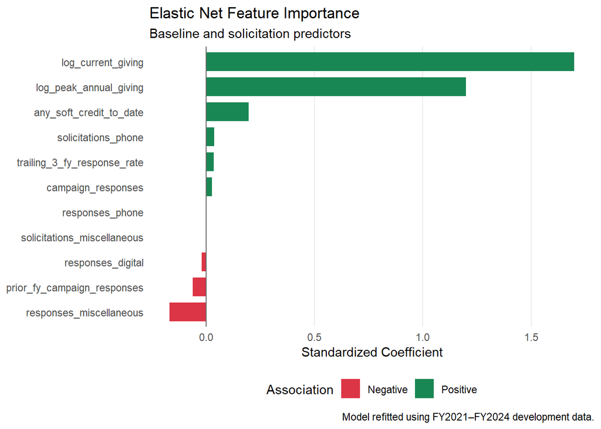

```r
feature_importance |>
  filter(coefficient != 0) |>
  mutate(
    predictor = forcats::fct_reorder(
      predictor,
      coefficient
    )
  ) |>
  ggplot(
    aes(
      x = coefficient,
      y = predictor,
      fill = direction
    )
  ) +
  geom_col(width = 0.75) +
  geom_vline(
    xintercept = 0,
    color = "gray40"
  ) +
  scale_fill_manual(
    values = c(
      "Positive" = "#198754",
      "Negative" = "#DC3545"
    )
  ) +
  labs(
    title = "Elastic Net Feature Importance",
    subtitle = "Baseline and solicitation predictors",
    x = "Standardized Coefficient",
    y = NULL,
    fill = "Association",
    caption = "Model refitted using FY2021–FY2024 development data."
  ) +
  theme_minimal() +
  theme(
    legend.position = "bottom",
    panel.grid.major.y = element_blank(),
    panel.grid.minor = element_blank()
  )
```

### Conclusions

This analysis evaluated the appropriate prospect population and the predictive value of solicitation-related features for identifying constituents likely to become major donors in the following fiscal year.

The prospect pool analysis demonstrated that constituents with positive current-year giving were substantially more likely to reach the $1,200 major-donor threshold than constituents with no recognized giving. Restricting the population to current donors reduced the eligible prospect pool by approximately 79.2% while retaining 91.3% of historically observed major-donor conversions. The baseline Logistic Regression comparison further supported this decision, with mean average precision increasing from 0.1212 to 0.1919, representing an approximately 58.33% relative improvement. Based on these findings, I selected constituents with recognized giving greater than $0 but less than $1,200 in the feature fiscal year as the population for subsequent modeling.

Compared with the reference Logistic Regression model using only the baseline predictors, Elastic Net with solicitation features achieved an approximately 1.09% relative improvement in mean average precision. These findings suggest that solicitation-related information may provide additional predictive value when combined with an appropriate modeling algorithm and regularization strategy. However, the relatively modest improvement indicates that historical giving information remains an important foundation for predicting major-donor conversion.

The next step is to integrate the solicitation features with the additional feature sets developed by the rest of the project team in a combined Group Modeling document. Alternative algorithms and feature configurations will be compared using chronological validation within the development dataset. The selected model will then be evaluated using FY2025 predictor data and observed FY2026 conversion outcomes, which have been reserved for independent final validation. This evaluation will help determine whether the predictive performance observed during model development generalizes to previously unseen data.

Ultimately, the objective is to provide PBS Utah with a reliable, data-driven approach to identifying promising major-donor prospects and prioritizing fundraising outreach.